# Conceptual figure

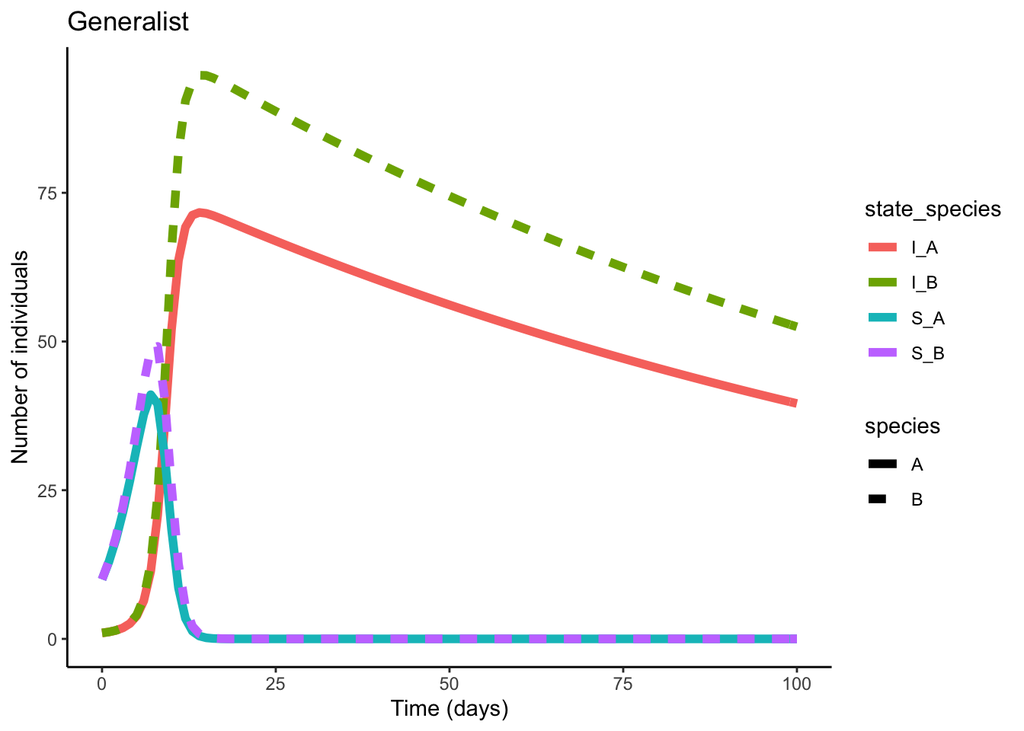

We will continue with a generalist pathogen, but assume unequal susceptibility. First, let’s assume species A is less susceptibility (i.e., $\beta_{AA} < \beta_{BA}$ and $\beta_{AB} < \beta_{BB}$.

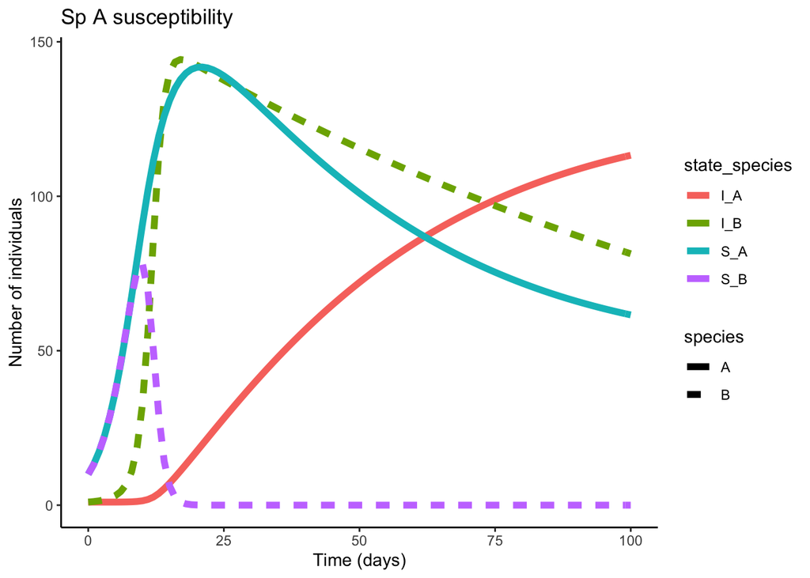

Now let’s assume species B is less susceptible (i.e., $\beta_{BB} < \beta_{AB}$ and $\beta_{BA} < \beta_{AA}$.

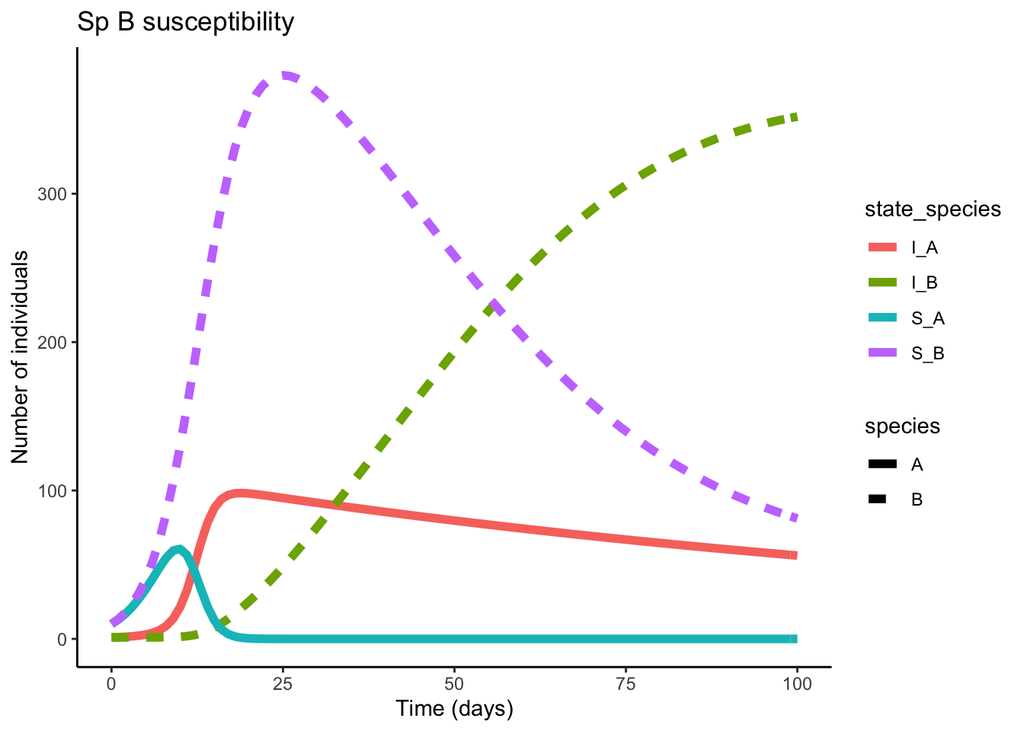

Now we will assume unequal competence. First, let’s assume species A is more competent (i.e., $\beta_{AA} > \beta_{AB}$ and $\beta_{BA} > \beta_{BB}$.

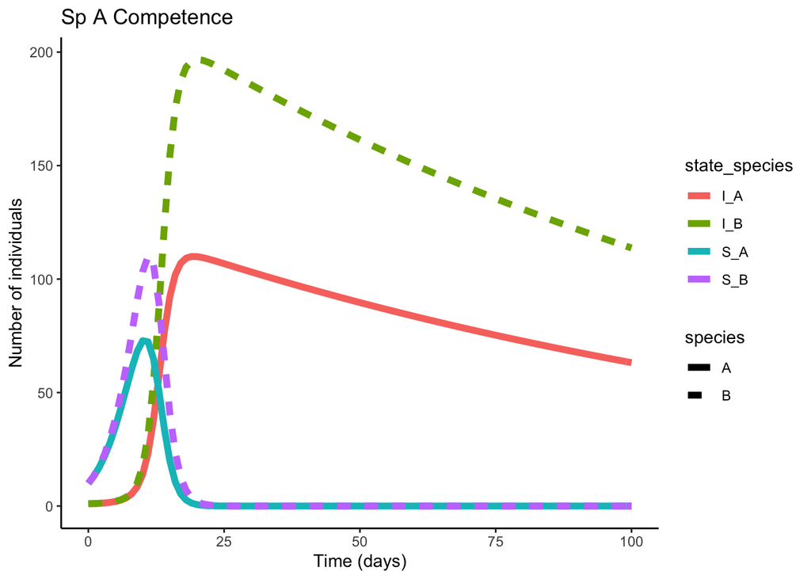

Next, let’s assume species B is more competent (i.e., $\beta_{BB} > \beta_{BA}$ and $\beta_{AB} > \beta_{AA}$.

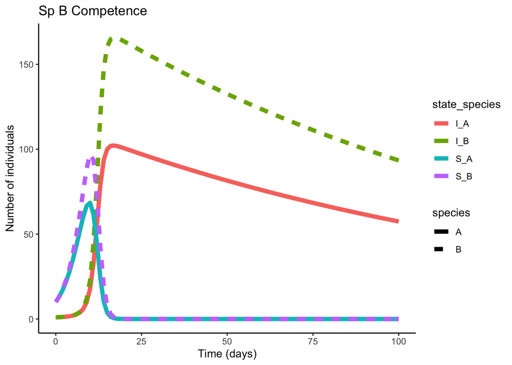

Now we will assume unequal tolerance. First, let’s assume species A is more tolerant (i.e., $v_{A} < b_{B}$.

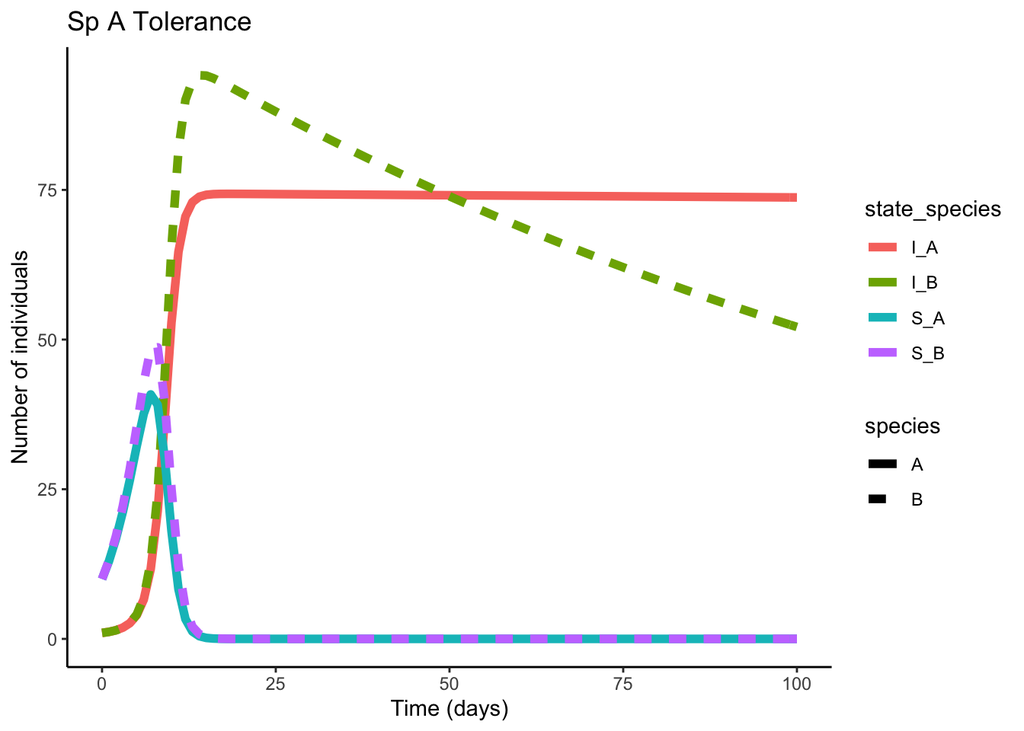

Now let’s assume species B is more tolerant (i.e., $v_{B} < b_{A}$.

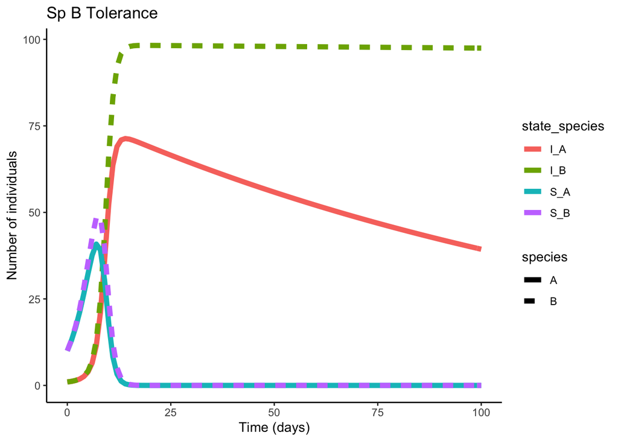

Finally, let’s assume species A is less susceptible and more tolerant.

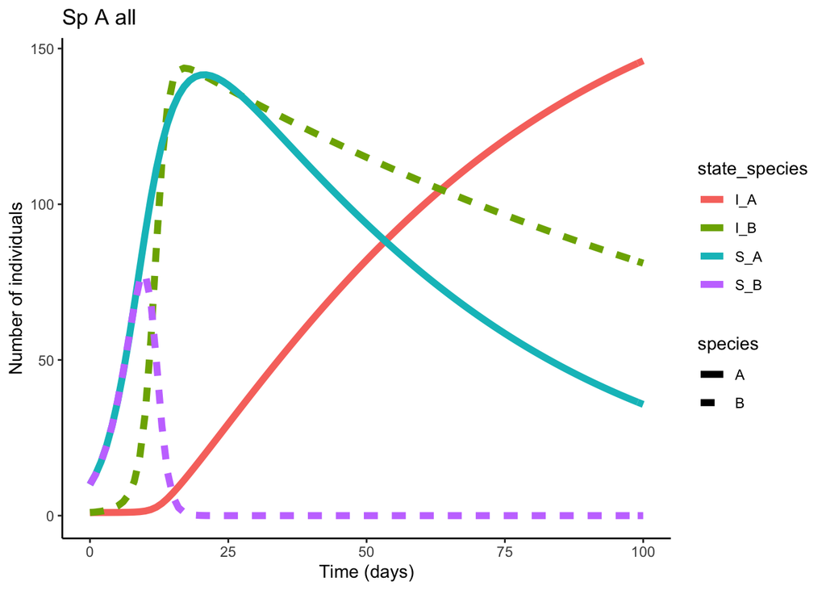

Now let’s assume species B is less susceptible and more tolerant.

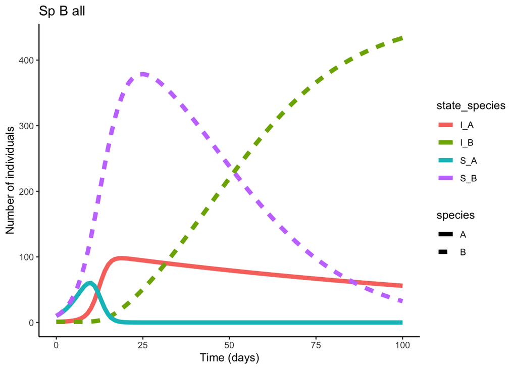